# Introduction

# Bivariate Exploration

First thing first, I want to see the relationship between numeric vs numeric, categorical vs categorical and numeric vs categorical. Lets see the correlation between the variables I have worked with before:

```python
var1 = ['LoanOriginalAmount', 'BorrowerAPR', 'StatedMonthlyIncome']
var2 = ['Term', 'ProsperRating (Alpha)','EmploymentStatus']
```

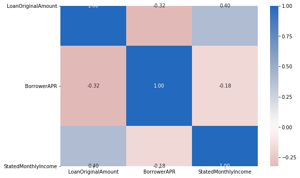

```python
plt.figure(figsize =[9,6])
sb.heatmap(loan_data_apr[var1].corr(), annot = True, fmt = '.2f',
            cmap = 'vlag_r', center = 0);
plt.yticks(rotation=0)
```

For some reason I can not make the graph be cut from the bottom and top! None of the parameters for https://seaborn.pydata.org/generated/seaborn.heatmap.html seem to help to make the graph look better!

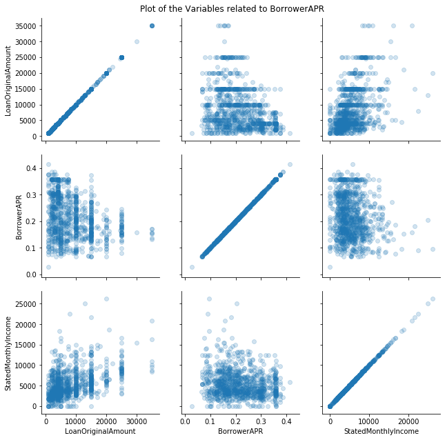

```python
loan_data_apr_sample = loan_data_apr.sample(1000)
s = sb.PairGrid(data = loan_data_apr_sample, vars = var1, size = 3)
s.map(plt.scatter, alpha = 0.2)
s.fig.suptitle('Plot of the Variables related to BorrowerAPR')
s.fig.subplots_adjust(top=.95)
```

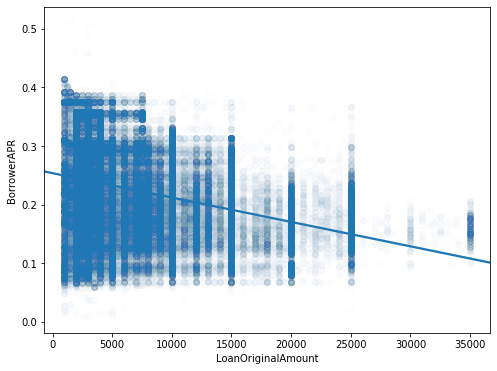

```python
plt.figure(figsize = [8, 6])
sb.regplot(data = loan_data_apr, x = 'LoanOriginalAmount', y = 'BorrowerAPR', scatter_kws={'alpha':0.01});
```

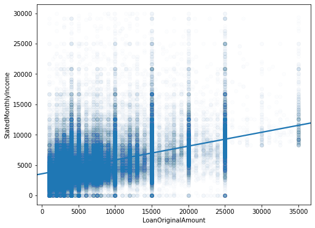

```python
#Just to the Plot between Loan Amount and Income as well.
plt.figure(figsize = [8, 6])
sb.regplot(data = loan_data_apr, x = 'LoanOriginalAmount', y = 'StatedMonthlyIncome', scatter_kws={'alpha':0.01});
```

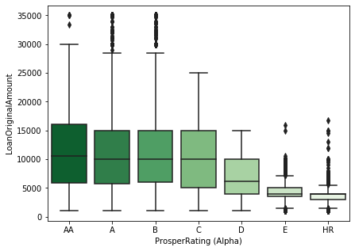

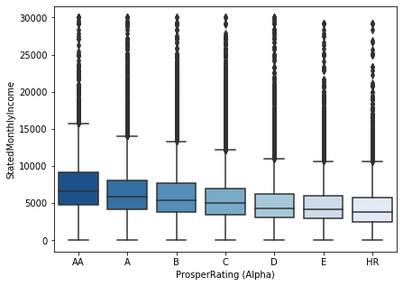

```python
#BoxPlot
plt.figure(figsize = [15, 5])
plt.subplot(1, 2, 1)
default_color = sb.color_palette()[0]
sb.boxplot(data = loan_data_apr, x = 'ProsperRating (Alpha)', y = 'LoanOriginalAmount', palette = 'Greens_r', order = rate_order)


plt.figure(figsize = [15, 5])
plt.subplot(1, 2, 1)
default_color = sb.color_palette()[0]
sb.boxplot(data = loan_data_apr, x = 'ProsperRating (Alpha)', y = 'StatedMonthlyIncome', palette = 'Blues_r', order = rate_order)
```

I do the Box Plot just to see what other information can be found when comparing different variables.

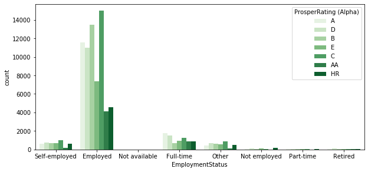

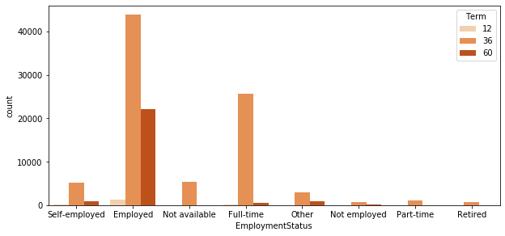

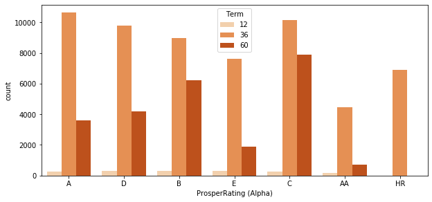

```python
# First Plot of Employment and Prosper Rating
plt.figure(figsize =[10,10])

plt.subplot(2,1,2)
sb.countplot(data=loan_data_apr, x = 'EmploymentStatus', hue = 'ProsperRating (Alpha)', palette = 'Greens' )

# The last two plots will be about Term vs Employment and Prosper Rating. Since term is in both of them I have decided to highlight it in Orange to make it visually pleasant
plt.figure(figsize =[10,10])

plt.subplot(2,1,2)
sb.countplot(data=loan_data_apr, x = 'EmploymentStatus', hue = 'Term', palette = 'Oranges' )

plt.figure(figsize =[10,10])
plt.subplot(2,1,2)
sb.countplot(data=loan_data_apr, x = 'ProsperRating (Alpha)', hue = 'Term', palette = 'Oranges' )
```

The three plots demonstrate this:

- Either there is not enough data for Not Available, Not Employed, Part-Time and Retired because compared to Term and Prosper Ratings, or the information is not impactfull enough.
- When comparing Prosper Ratings (Alpha) and Term we can see that there is a connection, especially since rating B and C have a 60 month loan. Even A and D rating are not far behind on the 60 month loan. On the other hand, AA has the least amount of the three month loan types compared to other ratings, not including HR because it only has a 36 month loan.

**Talk about some of the relationships you observed in this part of the investigation. How did the feature(s) of interest vary with other features in the dataset? Did you observe any interesting relationships between the other features (not the main feature(s) of interest**

On the other hand, I also ran a loan amount and a monthly income to find out that the correlation is actually possitive between thme. I guess the more money you have, the more money you cna loan. When it comes to the categorical variables, I saw when doing the Box Plot that a better Prosper Rating will have higher Income and Loan Original Data. The pure categorical data was also interesting and I explained my opinion about it in the code above.

# Miltivariate Exploration

Since before we worked on comparing variable to variable, in this part I want to compare the 'useful' (in my opinion) variable Prosper Rating and Term to variable Original Loan and Borrower APR.

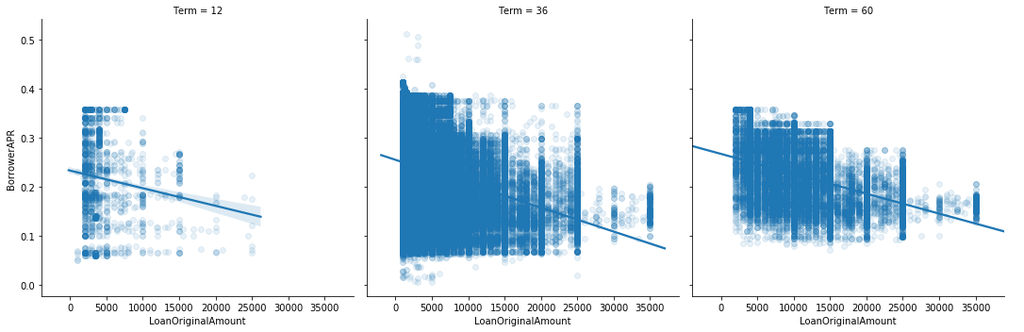

```python
term = sb.FacetGrid(data = loan_data_apr, col = 'Term', height = 5)
term.map(sb.regplot,'LoanOriginalAmount', 'BorrowerAPR', scatter_kws={'alpha':0.1});
term.add_legend()
```

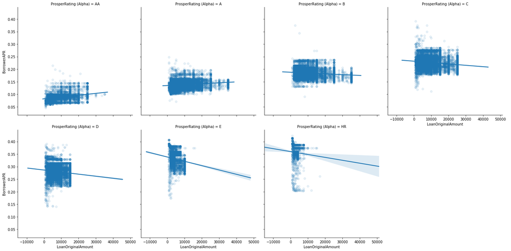

```python
rating = sb.FacetGrid(data = loan_data_apr, col = 'ProsperRating (Alpha)', height = 5, aspect = 1, col_wrap = 4, col_order = ['AA','A','B','C','D','E','HR'])
rating.map(sb.regplot,'LoanOriginalAmount', 'BorrowerAPR', x_jitter = 0.3, scatter_kws={'alpha':0.1});
rating.add_legend();
```

So from the plots above I can say the following: Term has no effect and is not affected by the Loan Amount and Borrower APR because we can see that the plots line does not change depending if it is 12, 36 or 60 month term; Loan Original Amount seems to be improving with a better Prosper Rating, but Borrower APR however get worse with a better Prosper Rating. We can also see that once the rating becomes A or AA, then the relation between APR and Loan Amount turns into a positive correlation.

Because the relationship goes from negative to positive it would be intereting to see on a better graph the difference. Thats why in the next plot I will try to further observe the change in Borrowers APR all depending on the Term and Prosper Rating (Alpha).

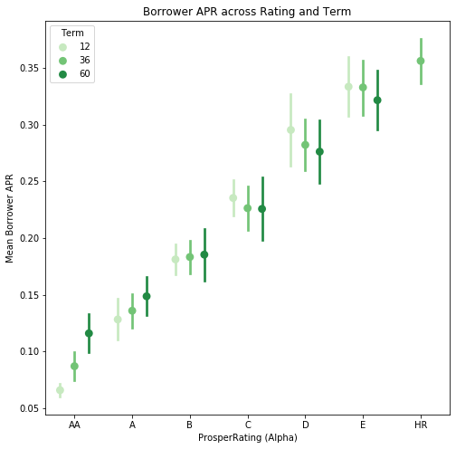

```python
plt.figure(figsize = [8,8])
point = sb.pointplot(data=loan_data_apr,  x = 'ProsperRating (Alpha)', y = 'BorrowerAPR', hue = 'Term',
                    palette = 'Greens', linestyles = '', dodge=0.5, ci = 'sd', order = rate_order)
plt.title('Borrower APR across Rating and Term')
plt.ylabel('Mean Borrower APR')
```

The only variable we have left to see the relation with is the Loan Original Amount. So what will happen with the variable once we put it against the Rating and Term as well.

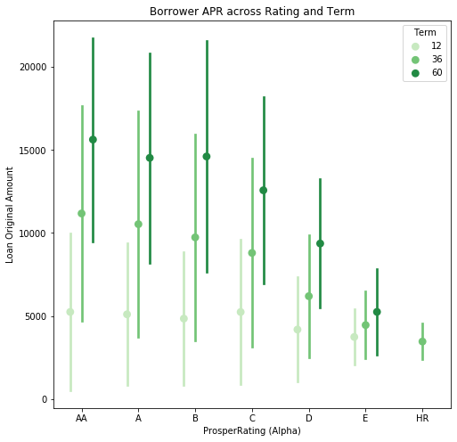

```python
plt.figure(figsize = [8,8])
point = sb.pointplot(data=loan_data_apr,  x = 'ProsperRating (Alpha)', y = 'LoanOriginalAmount', hue = 'Term',
                    palette = 'Greens', linestyles = '', dodge=0.4, ci = 'sd', order = rate_order)
plt.title('Borrower APR across Rating and Term')
plt.ylabel('Loan Original Amount')
```

Here on the other hand (comparing to Borrower APR), it is seen that Loan relationship with Term and Rating is better. As the Rating variable gets better, so does the Loan amount and also the borrow Term (from 12 to 60). But it doesnt just normally increases, but with a huge change compared to worse Ratings.

**Talk about some of the relationships you observed in this part of the investigation. Were there features that strengthened each other in terms of looking at your feature(s) of interest? Were there any interesting or surprising interactions between features**